[figure not shown]

### Fragmentación Electoral

El concepto de fragmentación electoral alude a la dispersión de los votos emitidos en relación con las opciones políticas (partidos, organizaciones o candidatos) que compiten en una determinada elección. Un indicador comúnmente usado para medir el grado de fragmentación electoral en un proceso electoral particular es el *Número Efectivo de Partidos (NEP).*

#### Elecciones Regionales

**Estadisticos descriptivos: Indicador de Fragmentación Electoral (NEP) en las Elecciones Regionales**

|  | 2002 | 2006 | 2010 | 2014 | 2018 |
| --- | --- | --- | --- | --- | --- |
| media | 5.39 | 5.27 | 5.44 | 5.82 | 5.74 |
| mediana | 5.28 | 5.37 | 5.25 | 5.50 | 5.32 |
| sd | 1.25 | 1.28 | 1.53 | 1.91 | 1.63 |
| min | 2.92 | 2.73 | 2.84 | 2.52 | 3.64 |
| max | 8.12 | 8.21 | 8.86 | 9.50 | 9.31 |

**Evolución en el tiempo: Indicador de Fragmentación Electoral (NEP) en las Elecciones Regionales**

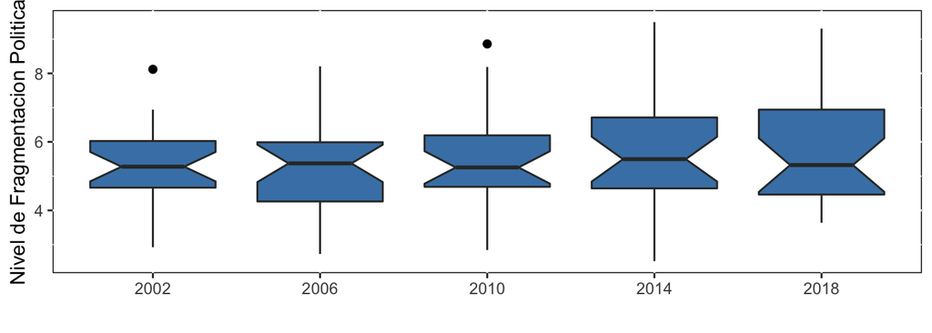

**Mapas Electorales: Indicador de Fragmentación Electoral (NEP) en las Elecciones Regionales**

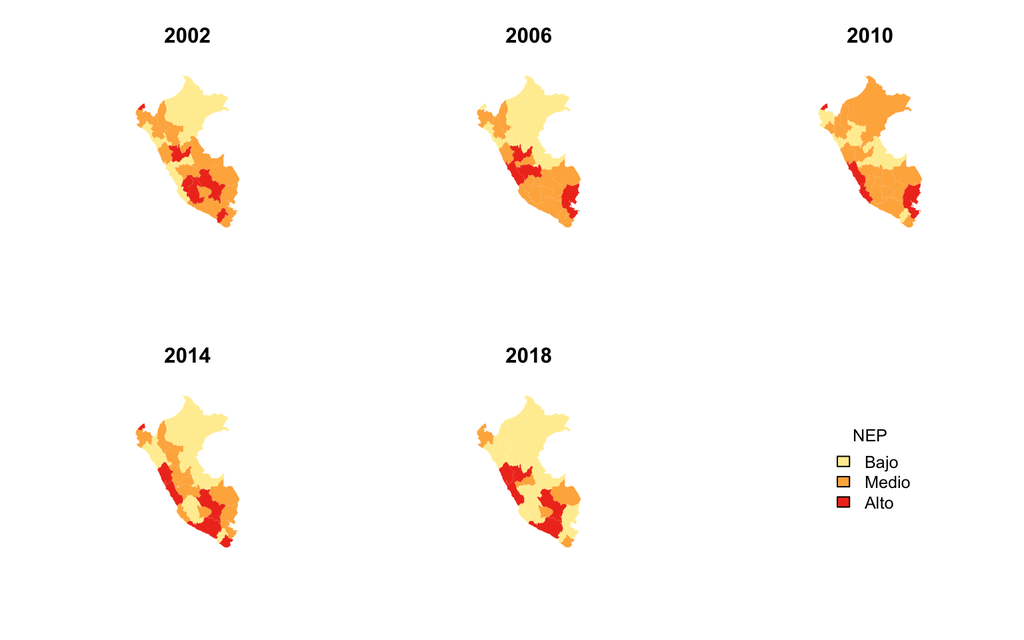

#### Elecciones Provinciales

**Estadisticos descriptivos: Indicador de Fragmentación Electoral (NEP) en las Elecciones Provinciales**

|  | 2002 | 2006 | 2010 | 2014 | 2018 |
| --- | --- | --- | --- | --- | --- |
| media | 5.92 | 5.34 | 5.25 | 5.34 | 5.32 |
| mediana | 5.55 | 5.22 | 5.14 | 5.18 | 5.08 |
| sd | 1.85 | 1.57 | 1.40 | 1.49 | 1.79 |
| min | 2.28 | 2.44 | 1.99 | 2.58 | 0.37 |
| max | 13.54 | 10.92 | 9.56 | 13.53 | 11.66 |

**Evolución en el tiempo: Indicador de Fragmentación Electoral (NEP) en las Elecciones Provinciales**

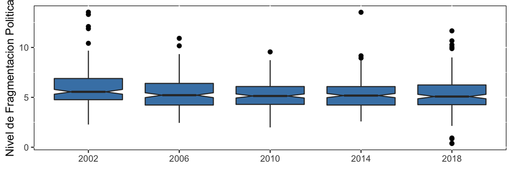

**Mapas Electorales: Indicador de Fragmentación Electoral (NEP) en las Elecciones Provinciales**

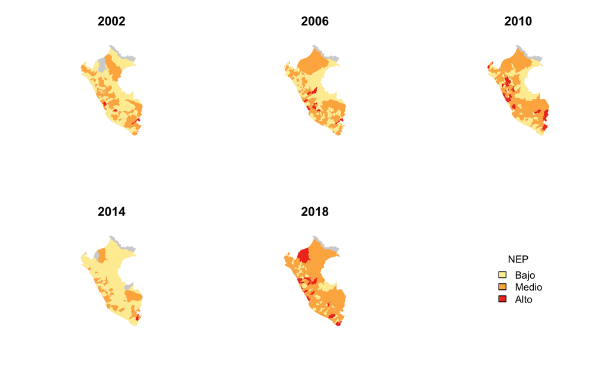

#### Análisis de Competitividad

El concepto de competitividad electoral alude a la distancia que se ha producido entre los partidos, organizaciones o candidatos que ocuparon el primer y el segundo lugar en un determinado proceso electoral. Por lo tanto el indicador comúnmente usado para medir el grado de competitividad registra la diferencia en la proporción de votos válidos emitidos entre las opciones electorales que quedaron en primer y segundo lugar.

#### Elecciones Regionales

**Estadisticos descriptivos: Indicador de Competitividad en las Elecciones Regionales**

|  | 2002 | 2006 | 2010 | 2014 | 2018 |
| --- | --- | --- | --- | --- | --- |
| media | 0.08 | 0.10 | 0.10 | 0.08 | 0.08 |
| mediana | 0.05 | 0.08 | 0.09 | 0.07 | 0.04 |
| sd | 0.07 | 0.08 | 0.07 | 0.07 | 0.08 |
| min | 0.00 | 0.00 | 0.00 | 0.01 | 0.00 |
| max | 0.29 | 0.34 | 0.31 | 0.26 | 0.27 |

**Evolución en el tiempo: Indicador de Competitividad en las Elecciones Regionales**

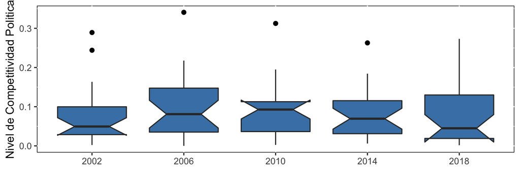

**Mapas Electorales: Indicador de Competitividad en las Elecciones Regionales**

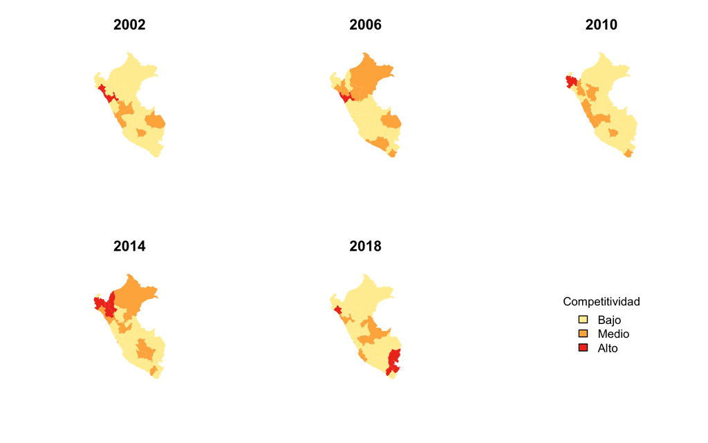

#### Elecciones Provinciales

**Estadisticos descriptivos: Indicador de Competitividad en las Elecciones Provinciales**

|  | 2002 | 2006 | 2010 | 2014 | 2018 |
| --- | --- | --- | --- | --- | --- |
| media | 0.07 | 0.08 | 0.07 | 0.07 | 0.08 |
| mediana | 0.05 | 0.06 | 0.05 | 0.06 | 0.05 |
| sd | 0.07 | 0.06 | 0.06 | 0.07 | 0.10 |
| min | 0.00 | 0.00 | 0.00 | 0.00 | 0.00 |
| max | 0.51 | 0.33 | 0.35 | 0.36 | 0.76 |

**Evolución en el tiempo: Indicador de Competitividad en las Elecciones Provinciales**

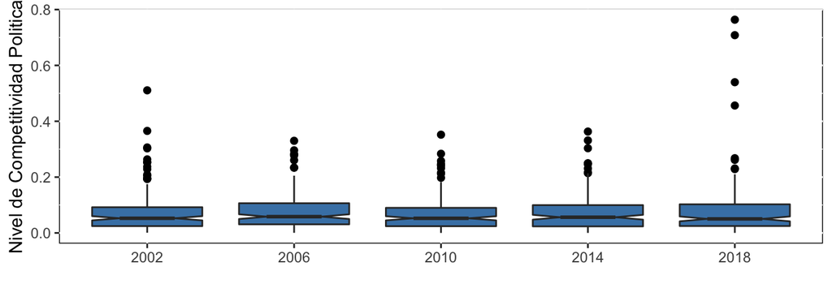

**Mapas Electorales: Indicador de Competitividad en las Elecciones Provinciales**

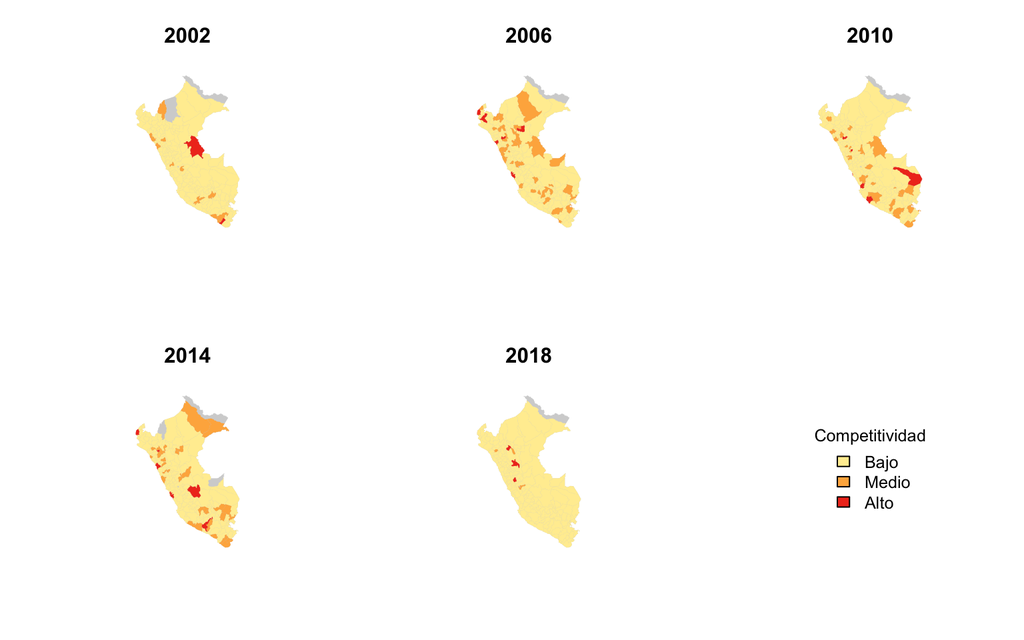

#### Elecciones Regionales

**Estadisticos descriptivos: Indicador de Concentracion en las Elecciones Regionales**

|  | 2002 | 2006 | 2010 | 2014 | 2018 |
| --- | --- | --- | --- | --- | --- |
| media | 0.51 | 0.53 | 0.54 | 0.52 | 0.47 |
| mediana | 0.50 | 0.52 | 0.53 | 0.51 | 0.48 |
| sd | 0.10 | 0.10 | 0.12 | 0.14 | 0.11 |
| min | 0.38 | 0.37 | 0.35 | 0.33 | 0.30 |
| max | 0.75 | 0.83 | 0.81 | 0.88 | 0.68 |

**Evolución en el tiempo: Indicador de Concentración Electoral (concentracion) en las Elecciones Regionales**

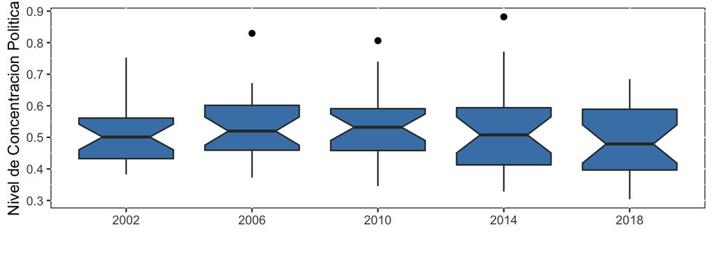

**Mapas Electorales: Indicador de Concentracion en las Elecciones Regionales**

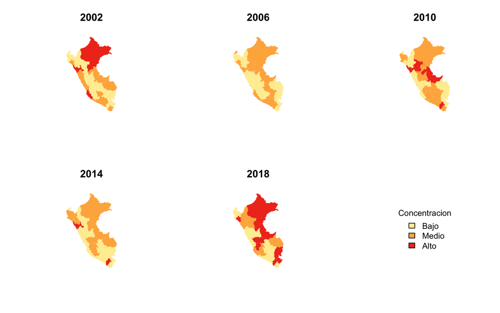

#### Elecciones Provinciales

**Estadisticos descriptivos: Indicador de Concentracion en las Elecciones Provinciales**

|  | 2002 | 2006 | 2010 | 2014 | 2018 |
| --- | --- | --- | --- | --- | --- |
| media | 0.49 | 0.52 | 0.53 | 0.52 | 0.55 |
| mediana | 0.48 | 0.50 | 0.51 | 0.51 | 0.52 |
| sd | 0.12 | 0.12 | 0.12 | 0.11 | 0.22 |
| min | 0.23 | 0.30 | 0.31 | 0.22 | 0.29 |
| max | 0.91 | 0.89 | 1.00 | 0.86 | 2.21 |

**Evolución en el tiempo: Indicador de concentracion en las Elecciones Provinciales**

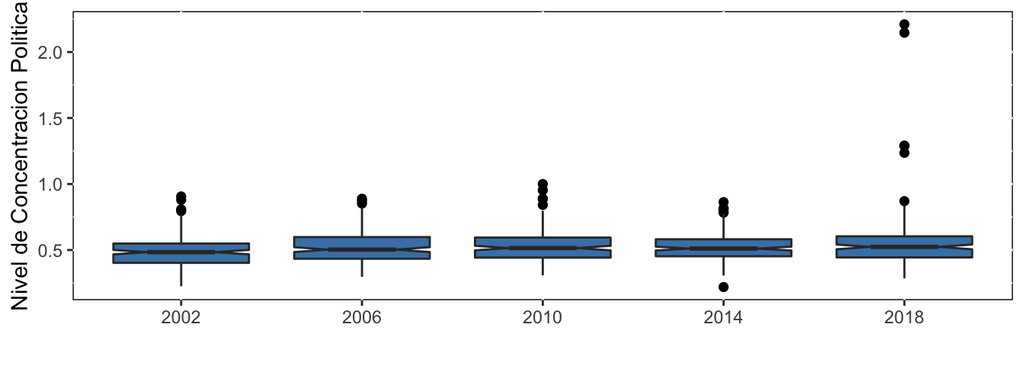

**Mapas Electorales: Indicador de concentracion en las Elecciones Provinciales**

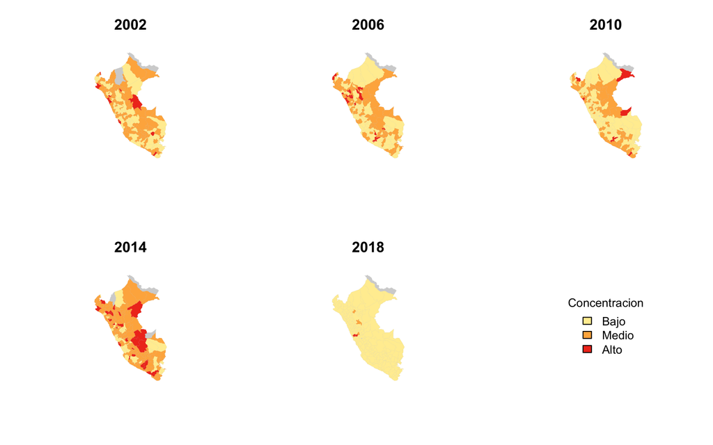

#### Elecciones Regionales

**Estadisticos descriptivos: Ausentismo a Nivel Regional**

|  | 2002 | 2006 | 2010 | 2014 | 2018 |
| --- | --- | --- | --- | --- | --- |
| media | 17.53 | 13.08 | 14.55 | 16.82 | 20.97 |
| mediana | 18.04 | 13.19 | 14.52 | 16.98 | 21.29 |
| sd | 4.71 | 2.57 | 2.79 | 2.97 | 3.83 |
| min | 9.70 | 8.76 | 10.27 | 12.11 | 14.85 |
| max | 24.66 | 17.04 | 19.27 | 23.54 | 30.37 |

**Evolución en el tiempo: Ausentismo a Nivel Regional**

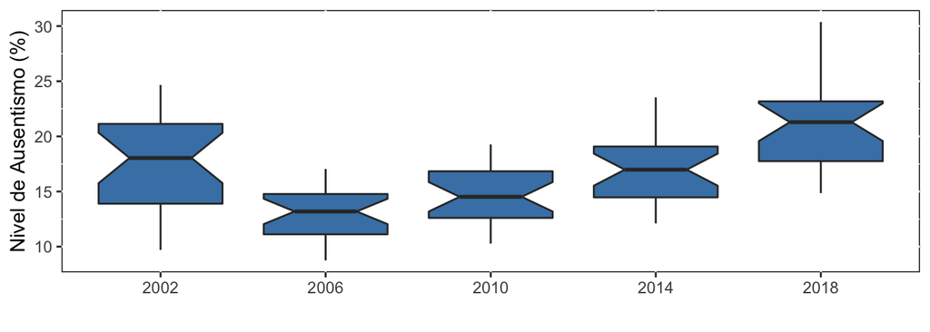

**Mapas Electorales: Ausentismo a Nivel Regional**

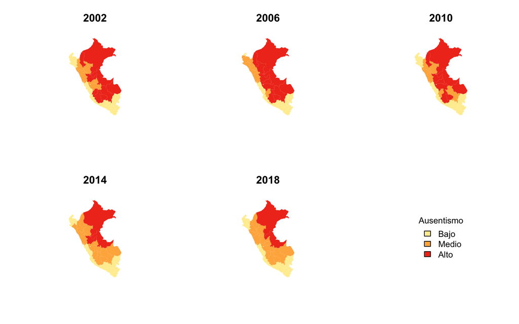

#### Elecciones Provinciales

**Estadisticos descriptivos: Ausentismo a Nivel Provincial**

|  | 2002 | 2006 | 2010 | 2014 | 2018 |
| --- | --- | --- | --- | --- | --- |
| media | 19.66 | 13.49 | 14.97 | 17.48 | 22.27 |
| mediana | 19.19 | 13.63 | 14.67 | 17.20 | 22.00 |
| sd | 5.93 | 3.13 | 3.69 | 3.95 | 5.01 |
| min | 7.97 | 5.33 | 6.28 | 7.32 | 12.03 |
| max | 35.57 | 23.14 | 34.89 | 30.88 | 43.42 |

**Evolución en el tiempo: Ausentismo a Nivel Provincial**

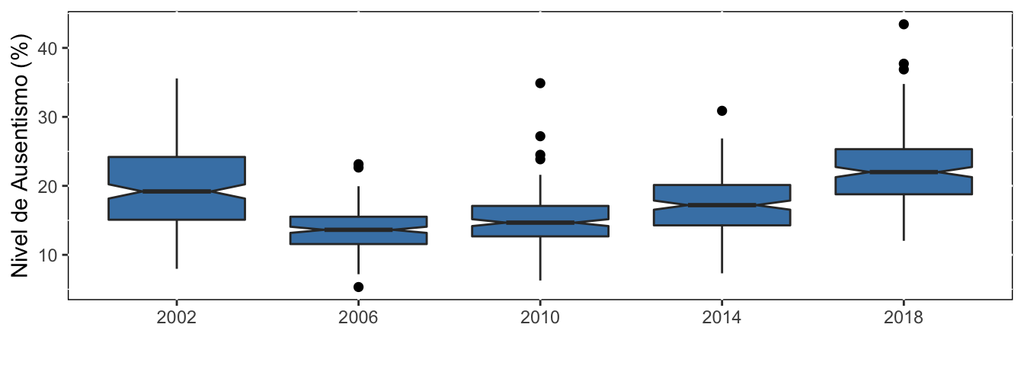

**Mapas Electorales: Ausentismo a Nivel Provincial**

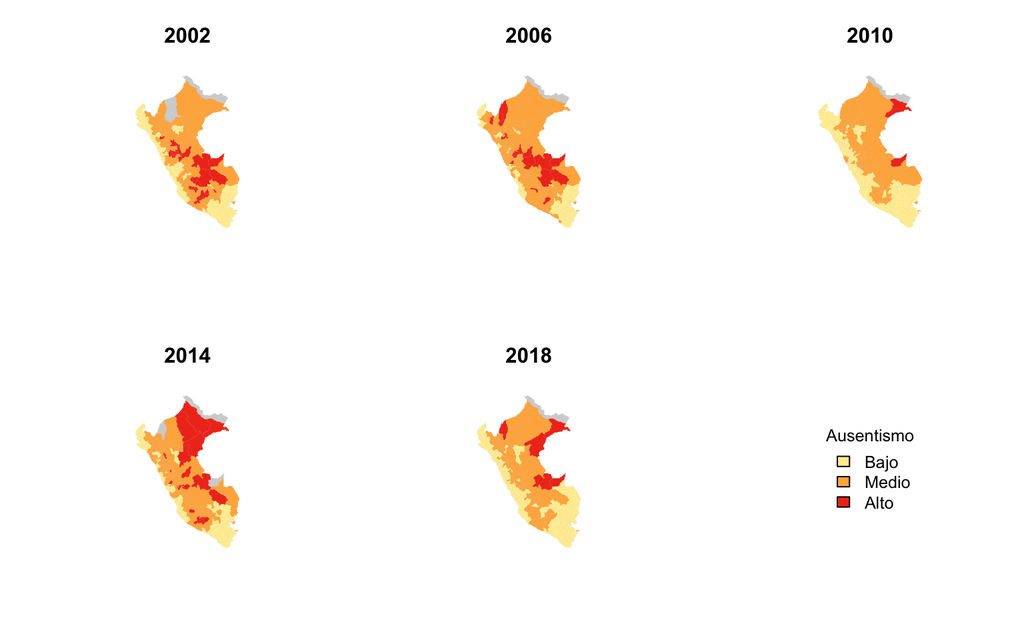

**El equipo del GIPSN está conformado por:**

- Jorge Aragón
- Francisco Aguilar
- María Gracia Becerra